# R4DS_2E_logicalVectors

Martin

2026-01-19

## Transform - Comparisons

1. How does dplyr::near() work? Type near to see the source code. Is sqrt(2)^2 near 2?

Answer: when typing near we get the following:

function (x, y, tol = .Machine$double.eps^0.5) { abs(x - y) < tol }

So its a function that takes two arguments x & y, calculates the absolute difference between them and sees if its less then the given tol (tolerance) which is a default value of `.Machine$double.eps^0.5` which is the value 1.490116e-08. It is a very small number

```r
sqrt_2 <- sqrt(2)^2
near(2, sqrt_2)
```

```
## [1] TRUE
```

```r
# Sqrt(2)^2 is near 2
```

2. Use mutate(), is.na(), and count() together to describe how the missing values in dep_time, sched_dep_time and dep_delay are connected.

```r
NA_flights <- nycflights13::flights |>
  mutate(
    dep_time_miss = is.na(dep_time),
    sched_dep_time_miss = is.na(sched_dep_time),
    dep_delay_miss = is.na(dep_delay)
  )

count(NA_flights, dep_time_miss, sched_dep_time_miss, dep_delay_miss)
```

```
## # A tibble: 2 × 4
##   dep_time_miss sched_dep_time_miss dep_delay_miss      n
##   <lgl>         <lgl>               <lgl>           <int>
## 1 FALSE         FALSE               FALSE          328521
## 2 TRUE          FALSE               TRUE             8255
```

```r
# There seems to be a connection that when the dep_delay is a missing value the dep_time is also a missing value respectively. That makes sense, if the dep_time wasn't recorded, how can we record a dep_delay? all three combined don't appear to be connected
```

## Transform - Boolean algebra

1. Find all flights where arr_delay is missing but dep_delay is not. Find all flights where neither arr_time nor sched_arr_time are missing, but arr_delay is.

```r
flights |>
  filter(is.na(arr_delay) & !is.na(dep_delay))
```

```
## # A tibble: 1,175 × 19
##     year month   day dep_time sched_dep_time dep_delay arr_time sched_arr_time
##    <int> <int> <int>    <int>          <int>     <dbl>    <int>          <int>
##  1  2013     1     1     1525           1530        -5     1934           1805
##  2  2013     1     1     1528           1459        29     2002           1647
##  3  2013     1     1     1740           1745        -5     2158           2020
##  4  2013     1     1     1807           1738        29     2251           2103
##  5  2013     1     1     1939           1840        59       29           2151
##  6  2013     1     1     1952           1930        22     2358           2207
##  7  2013     1     1     2016           1930        46       NA           2220
##  8  2013     1     2      905            822        43     1313           1045
##  9  2013     1     2     1125            925       120     1445           1146
## 10  2013     1     2     1848           1840         8     2333           2151
## # ℹ 1,165 more rows
## # ℹ 11 more variables: arr_delay <dbl>, carrier <chr>, flight <int>,
## #   tailnum <chr>, origin <chr>, dest <chr>, air_time <dbl>, distance <dbl>,
## #   hour <dbl>, minute <dbl>, time_hour <dttm>
```

```r
flights |>
  filter(!is.na(arr_time) & !is.na(sched_arr_time) & is.na(arr_delay))
```

```
## # A tibble: 717 × 19
##     year month   day dep_time sched_dep_time dep_delay arr_time sched_arr_time
##    <int> <int> <int>    <int>          <int>     <dbl>    <int>          <int>
##  1  2013     1     1     1525           1530        -5     1934           1805
##  2  2013     1     1     1528           1459        29     2002           1647
##  3  2013     1     1     1740           1745        -5     2158           2020
##  4  2013     1     1     1807           1738        29     2251           2103
##  5  2013     1     1     1939           1840        59       29           2151
##  6  2013     1     1     1952           1930        22     2358           2207
##  7  2013     1     2      905            822        43     1313           1045
##  8  2013     1     2     1125            925       120     1445           1146
##  9  2013     1     2     1848           1840         8     2333           2151
## 10  2013     1     2     1849           1724        85     2235           1938
## # ℹ 707 more rows
## # ℹ 11 more variables: arr_delay <dbl>, carrier <chr>, flight <int>,
## #   tailnum <chr>, origin <chr>, dest <chr>, air_time <dbl>, distance <dbl>,
## #   hour <dbl>, minute <dbl>, time_hour <dttm>
```

2. How many flights have a missing dep_time? What other variables are missing in these rows? What might these rows represent?

```r
flights |>
  count(is.na(dep_time))
```

```
## # A tibble: 2 × 2
##   `is.na(dep_time)`      n
##   <lgl>              <int>
## 1 FALSE             328521
## 2 TRUE                8255
```

```r
# 8255 flights having a missing dep_time

flights |>
  filter(is.na(dep_time))
```

```
## # A tibble: 8,255 × 19
##     year month   day dep_time sched_dep_time dep_delay arr_time sched_arr_time
##    <int> <int> <int>    <int>          <int>     <dbl>    <int>          <int>
##  1  2013     1     1       NA           1630        NA       NA           1815
##  2  2013     1     1       NA           1935        NA       NA           2240
##  3  2013     1     1       NA           1500        NA       NA           1825
##  4  2013     1     1       NA            600        NA       NA            901
##  5  2013     1     2       NA           1540        NA       NA           1747
##  6  2013     1     2       NA           1620        NA       NA           1746
##  7  2013     1     2       NA           1355        NA       NA           1459
##  8  2013     1     2       NA           1420        NA       NA           1644
##  9  2013     1     2       NA           1321        NA       NA           1536
## 10  2013     1     2       NA           1545        NA       NA           1910
## # ℹ 8,245 more rows
## # ℹ 11 more variables: arr_delay <dbl>, carrier <chr>, flight <int>,
## #   tailnum <chr>, origin <chr>, dest <chr>, air_time <dbl>, distance <dbl>,
## #   hour <dbl>, minute <dbl>, time_hour <dttm>
```

```r
# For these rows it also looks like dep_delay, arr_time, arr_delay and air_time are all missing respectively. This makes sense if the flights are cancelled.
```

3. Assuming that a missing dep_time implies that a flight is cancelled, look at the number of cancelled flights per day. Is there a pattern? Is there a connection between the proportion of cancelled flights and the average delay of non-cancelled flights?

```r
cancelled_and_delays <-
  flights %>%
  mutate(cancelled = (is.na(arr_delay) | is.na(dep_delay))) %>%
  group_by(year, month, day) %>%
  summarise(
    cancelled_prop = mean(cancelled),
    avg_dep_delay = mean(dep_delay, na.rm = TRUE),
    avg_arr_delay = mean(arr_delay, na.rm = TRUE)
  ) %>%
  ungroup()
```

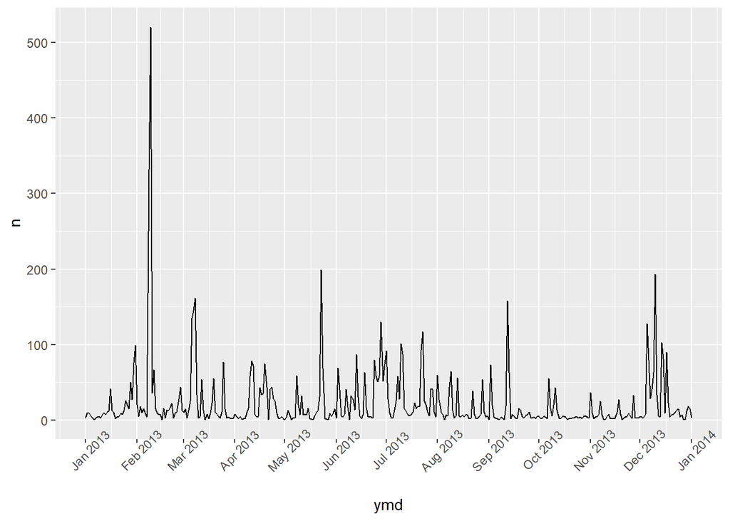

```r
cancelled_flights <- flights |>
  mutate(ymd = as.Date(time_hour)) |>
  group_by(ymd) |>
  count(is.na(dep_time))

cancelled_flights |>
  filter(`is.na(dep_time)` == TRUE) |>
  ggplot(aes(ymd, n)) +
  geom_line() +
  scale_x_date(date_labels = "%b %Y", date_breaks = "1 month") +
  theme(axis.text.x = element_text(angle = 45))
```